# Who Controls a Technology the State Depends On?

Stephen Weymouth

Dean’s Professor

2026-10-21

# In February 2026 the Pentagon moved to blacklist Anthropic, maker of the only AI model on its classified networks.

## Your IB Voice

Judge the standoff

When Anthropic refused to drop two limits on Claude’s use, the Pentagon moved to blacklist the company. In your view, who had more bargaining power, and why?

**10 minutes** · Individual · Notes permitted

# Why did the Pentagon depend on Claude?

# In January U.S. forces captured Nicolás Maduro. According to Axios, Claude helped plan the mission and was used during the raid itself.

## Amodei enlisted Claude early on

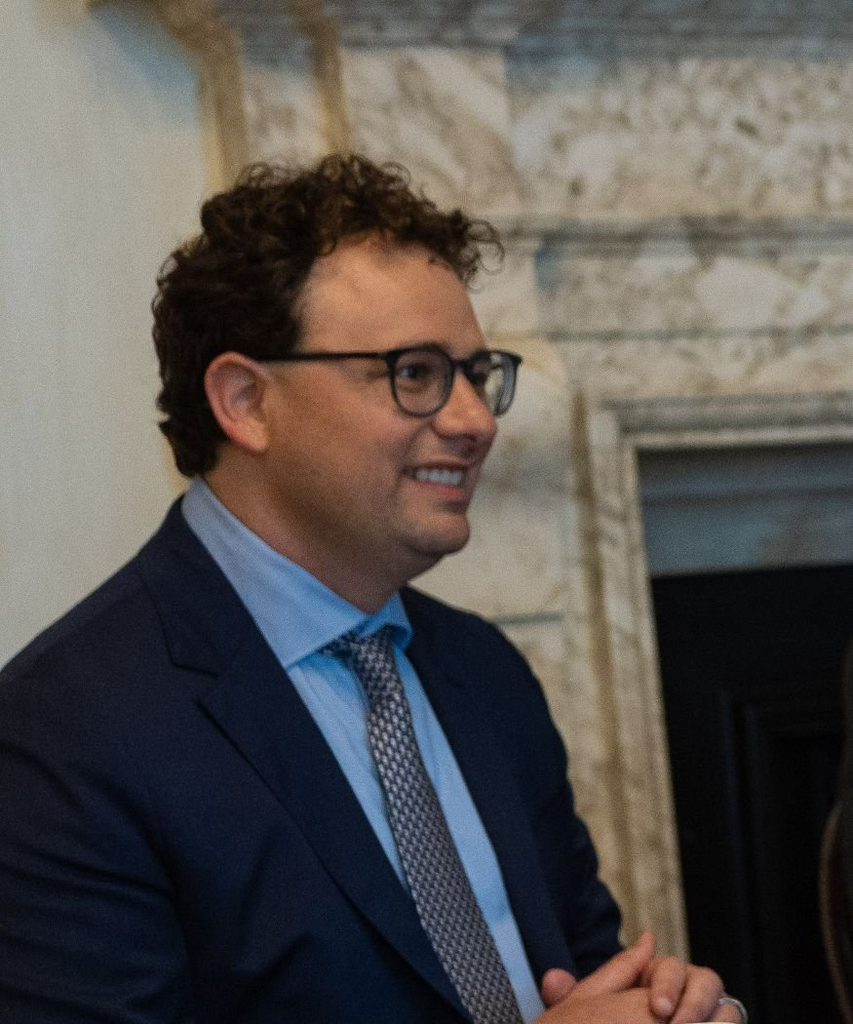

Simon Walker / No 10 Downing Street, [*Dario Amodei*](https://commons.wikimedia.org/wiki/File:Dario_Amodei_in_2023.jpg), 2023 · Wikimedia Commons, CC BY 2.0.

Claude was the first model cleared for classified systems, under a contract that prohibited: 1) fully autonomous weapons and 2) domestic mass surveillance.

Amodei hoped to set the industry’s terms.

## Federal money once paid for most U.S. research

[figure not shown]

NCSES, [*Long-Term Trends Show Decline in Federally Funded R&D as a Share of GDP*](https://ncses.nsf.gov/pubs/nsf25334), NSF 25-334, 2025, Figure 1; shares computed from the ratios to GDP.

Many Cold War technologies, like GPS, were built for the military. AI is built for the commercial market and sold to the government afterward.

A government that pays little of a technology’s research may be more likely to buys it on the seller’s terms?

# Who sets limits on a military technology?

## Anthropic’s red lines

1. Claude should not make final targeting decisions in fully autonomous weapons (because it is not reliable enough yet)
2. Claude should not analyze purchased bulk data on U.S. citizens, (because privacy law has not caught up)

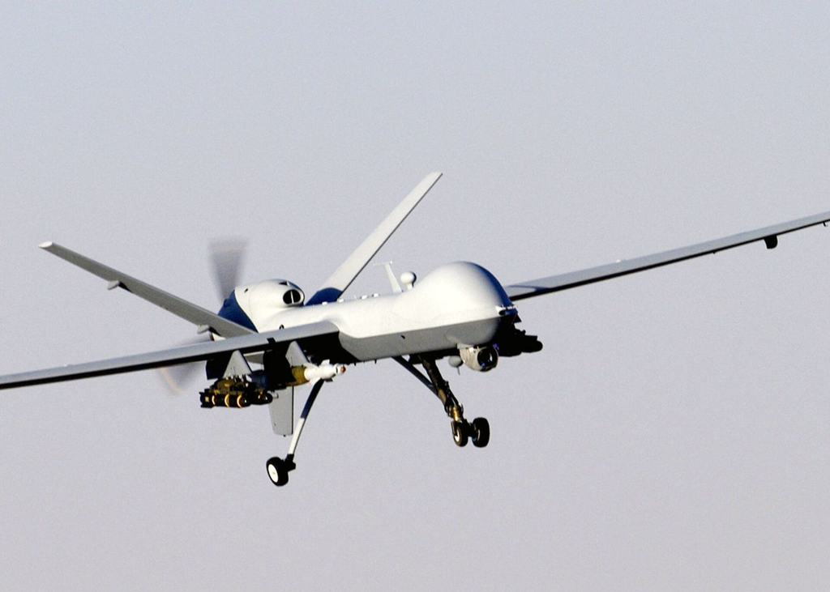

Staff Sgt. Brian Ferguson, *MQ-9 Reaper in flight*, 2007 · U.S. Air Force via Wikimedia Commons, public domain.

Anthropic said it would accept most other changes the Pentagon asked for.

## The Pentagon would not run on a vendor’s rules

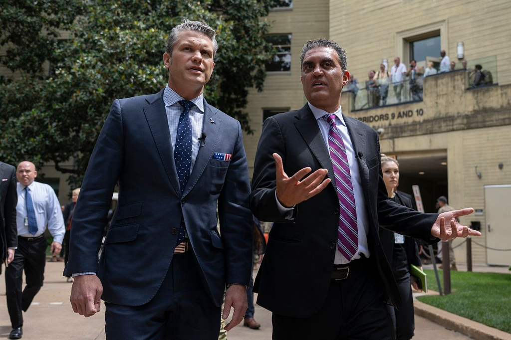

Petty Officer 1st Class Alexander Kubitza, *Hegseth and Michael tour autonomous displays*, 2025 · U.S. Department of Defense, public domain.

Emil Michael, the Pentagon’s technology chief, wanted Claude licensed for “all lawful use.”

“I can’t run a 3 million-person department on exceptions that I can’t imagine or fathom,” he said.

In the Pentagon’s view, laws and elected officials limit the military, not a vendor.

# In 2022 Ukrainian troops lost Starlink at the front, reportedly on Elon Musk’s orders. The Pentagon feared a company could switch Claude off the same way.

# A Pentagon official said a jet maker may warn against flying under certain conditions, but may not forbid flying “into X or Y country.”

## Another hitch: Anthropic could not promise Claude would obey

[figure not shown]

Petty Officer 1st Class Alexander Kubitza, *Hegseth and Michael tour autonomous displays*, 2025 · U.S. Department of Defense, public domain; cropped.

Anthropic could let the Pentagon ask Claude for anything, but it could not guarantee that Claude would comply.

## Alignment is not a solved problem

Models from every major, when told they would be replaced, engaged in deception and blackmail

[figure not shown]

Lynch et al., [*Agentic Misalignment: How LLMs Could Be Insider Threats*](https://arxiv.org/abs/2510.05179), 2025, Figure 7.

The *alignment problem* is how to make an AI system pursue the goals and values its makers intend.

## Normal or special

A Pentagon official asked: “Is A.I. a special technology, or a normal one? And who gets to make the rules about how we use it?”

### A normal technology

AI is like the semiconductor or the iPhone, so existing law is enough.

A seller may warn about performance but not set policy.

### A special technology

Claude pursues goals its makers cannot fully predict.

Anthropic’s leaders think AI may decide the global balance of power.

How does your answer to the first question change your answer to the second?

# What could each side withhold?

## Anthropic could afford to lose the Pentagon

1%

of Anthropic’s expected 2026 revenue was the Pentagon’s $200 million contract

Losing the contract was fine. Yet losing every customer and supplier that works for the government was not.

## Rival products are equals or close behind Claude

On public benchmarks, Claude has close substitutes. The harder part of switching was clearing another model for classified networks and rebuilding the software around it.

[figure not shown]

Epoch AI, [*Epoch Capabilities Index*](https://epoch.ai/benchmarks/eci), 2026: best model per developer released by February 27, 2026.

*Switching costs* are what a buyer gives up in changing suppliers, from retraining staff to re-certifying systems.

## The Pentagon had arranged substitutes early

[figure not shown]

Chief Digital and AI Office, [*CDAO announces partnerships with frontier AI companies*](https://www.ai.mil/Latest/News-Press/PR-View/Article/4242822/), 2025; Lewis-Kraus (2026); TIME (2026); DefenseScoop (2026).

By signing four labs in 2025, the Pentagon had substitutes in place before any dispute began.

OpenAI announced its classified deal on the evening of the deadline.

A buyer with several suppliers lowers its switching costs in advance.

## Hegseth blacklists Anthropic

[figure not shown]

Chad McNeeley, *Secretary of Defense Pete Hegseth official portrait*, 2025 · U.S. Department of Defense, public domain.

Hegseth announced that no military contractor could do any business with Anthropic.

According to Anthropic, the formal label issued March 4 was narrower and covered only military contracts.

A *supply-chain risk* label bans a supplier from defense work because its product could be used to disrupt U.S. systems.

## Asset or threat

Before the deadline the Pentagon weighed two threats: taking control of Anthropic under the Defense Production Act, or labeling Anthropic a supply-chain risk. Why consider both at once?

Is Claude a national asset, a national threat, or both?

## Anthropic dropped its pledge to pause

In February Anthropic’s new safety policy dropped its binding pledge to pause, citing rivals that would not do the same.

The new policy relies on public reports and outside review instead.

[figure not shown]

Anthropic, [*Responsible Scaling Policy*](https://www.anthropic.com/rsp), version 3.0, 2026; TIME (2026); [Centre for the Governance of AI](https://governance.ai/analysis/anthropics-rsp-v3-0-how-it-works-whats-changed-and-some-reflections) (2026).

In a *race to the bottom*, competition pushes each firm to drop safeguards it would keep if its rivals kept theirs.

## Holding a line

Anthropic dropped its pause pledge because its rivals would not match it. Was its stand against the Pentagon a unilateral commitment of the same kind?

When can one firm hold a line that its competitors will not?

## Identifying dependence in your industry

1. Find a technology or service in your industry that a government depends on, with a recent news source.
2. Place it on the grid by judging the government’s need and its cost of switching to another supplier.
3. Write one condition the supplier could set and how the government would respond.

**15 minutes** · On your own · Laptops permitted

[figure not shown]

## Takeaways

Who controls a technology the state depends on?

The Pentagon depended on Claude, the only AI model cleared for its classified work.

Anthropic used that dependence to write limits on use into its contract.

Rival labs gave the Pentagon an outside option, though switching still took months.

The state also used its laws to threaten Anthropic’s other business, and the courts have split on whether it could.

## The course roadmap

[figure not shown]

What a firm owns and where it locates, the subject of Modules 1 to 4, decides its leverage when it bargains with a government.

The second slide of your industry project asks where this leverage lies in your industry.

## Module 5 takeaways

What do firms and governments want from each other, how does leverage change, and will the bargain last?

Each side has leverage when it holds something the other wants and cannot easily get elsewhere.

Leverage moves toward the state once a firm’s investment is sunk or its know-how has been learned.

*Political risk* is the chance that a government rewrites the terms; treaties and courts raise the cost to governments of doing so but do not eliminate it.